# II samba sissemaksete analüüs

Andmed: [Pensionikeskus](https://www.pensionikeskus.ee/statistika/ii-sammas/ii-samba-sissemaksete-ulevaade/), jaanuar 2020 – september 2026.

Analüüs tehtud [Claude Code](https://claude.ai/claude-code) abiga 1. aprillil 2026, umbes 2 tunniga algsest ideest valmis raportini. Andmed uuendatud oktoobris 2026.

**NB:** Juulist 2020 kuni oktoobrini 2021 peatas riik oma osa (~2/3) II samba sissemaksetest. Peatatud sissemaksed kompenseeriti ühekordse maksena jaanuaris 2023. Need kuud on analüüsist välja jäetud.

## Sissemaksed fondide kaupa

Peamine trend: indeksfondide (sinisega) osakaal sissemaksetes kasvab iga fondihalduri juures. Indeksfondide osakaal halduri sissemaksetes (I kv 2020 → september 2026):

- **SEB:** 5% → 48%
- **Swedbank:** 2% → 44% (sh Swedbank K1990 indeksfond)
- **LHV:** 5% → 32%
- **Luminor:** 0% → 12%
- **Tuleva** on 100% indeksfondid ja turuosa on kasvanud 4% → 16%

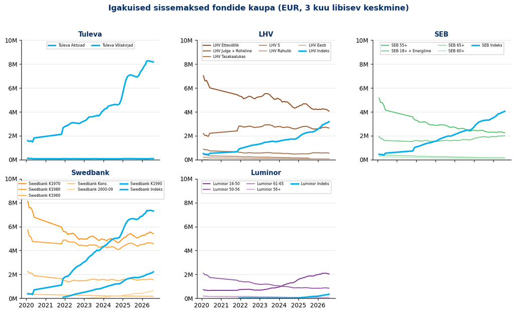

*Ühinenud fondid on näidatud ühe joonena: LHV Roheline sisaldub LHV Julges (ühinesid septembris 2025) ja SEB Energiline SEB 18+ fondis (ühinesid jaanuaris 2024).*

Sama trend on näha ka isikute arvus. Indeksfondi valinud isikute osakaal halduri sees (I kv 2020 → september 2026):

- **SEB:** 4% → 45%
- **Swedbank:** 3% → 42% (sh Swedbank K1990)
- **LHV:** 4% → 32%
- **Luminor:** 0% → 18%
- **Tuleva** turuosa isikute arvus: 3% → 10%

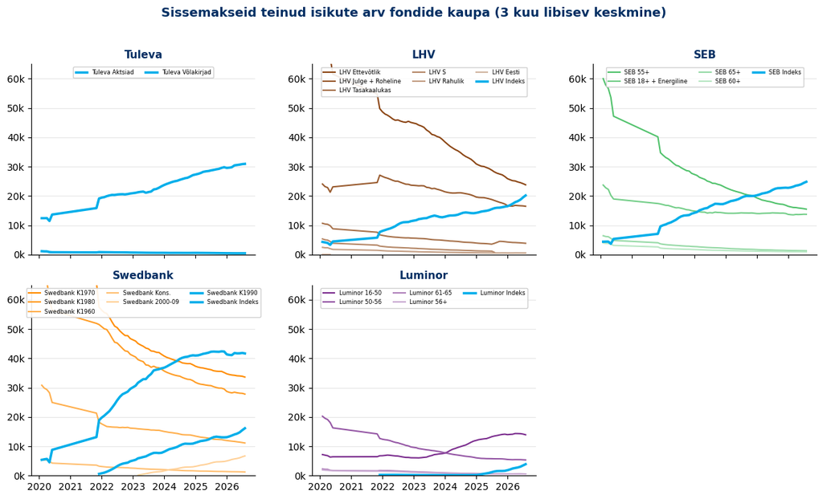

*Ühinenud fondid on näidatud ühe joonena: LHV Roheline sisaldub LHV Julges (ühinesid septembris 2025) ja SEB Energiline SEB 18+ fondis (ühinesid jaanuaris 2024).*

## Tuleva vs indeksfondid vs ülejäänud

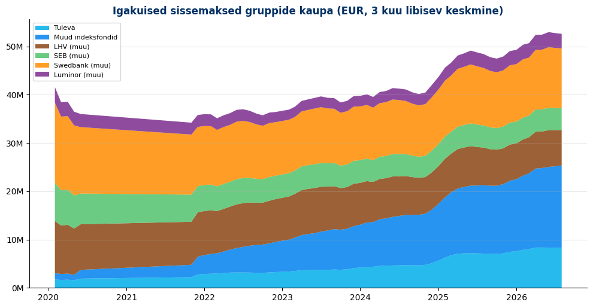

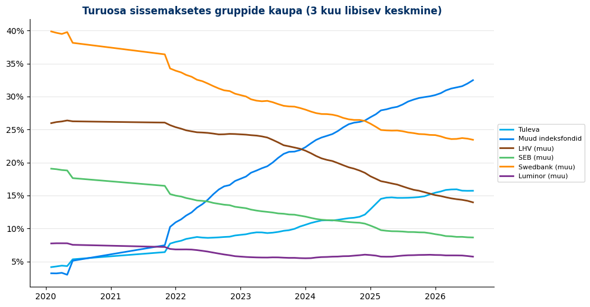

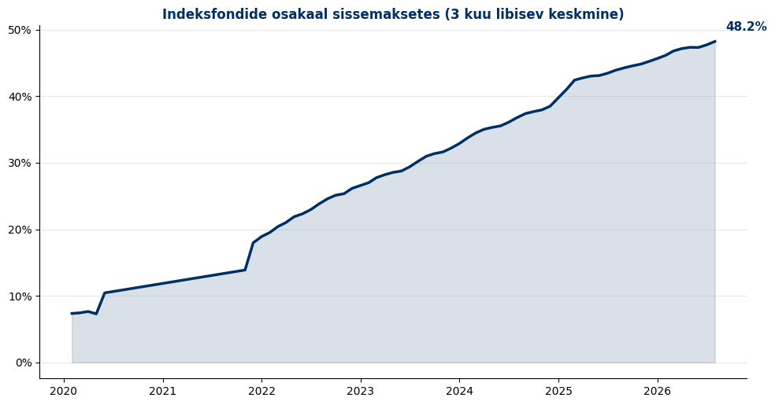

## Sissemaksed fondihalduri kaupa

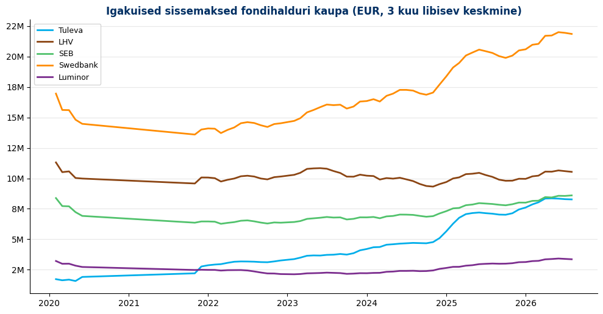

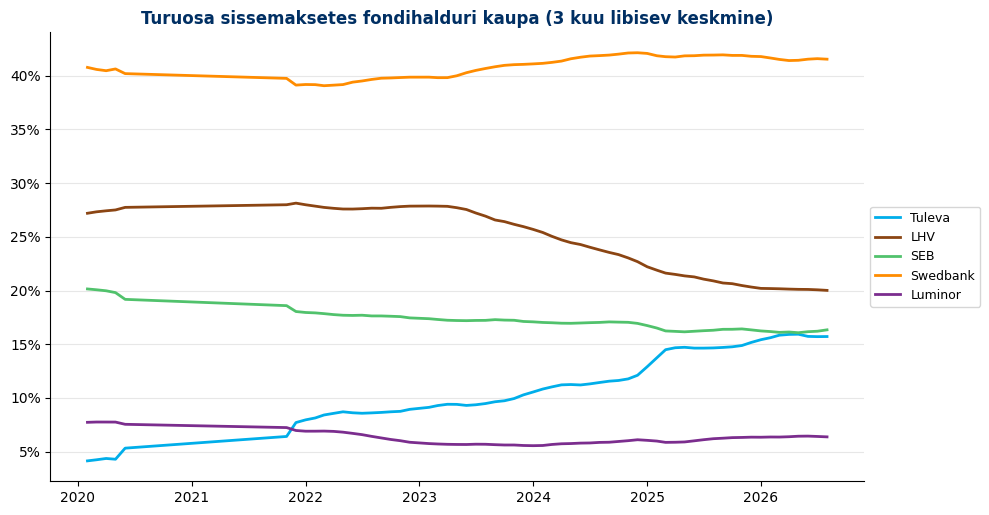

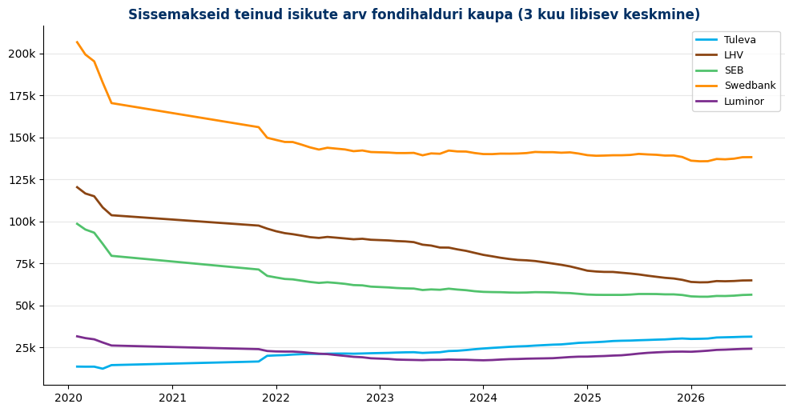